# Practical Machine Learning course project

### **Background**

Taken from: http://web.archive.org/web/20161224072740/http:/groupware.les.inf.puc-rio.br/har

In this work (see the paper) we first define quality of execution and investigate three aspects that pertain to qualitative activity recognition: the problem of specifying correct execution, the automatic and robust detection of execution mistakes, and how to provide feedback on the quality of execution to the user. We tried out an on-body sensing approach (dataset here), but also an “ambient sensing approach” (by using Microsoft Kinect - dataset still unavailable)

Six young health participants were asked to perform one set of 10 repetitions of the Unilateral Dumbbell Biceps Curl in five different fashions:  
* exactly according to the specification (Class A),

- throwing the elbows to the front (Class B),
- lifting the dumbbell only halfway (Class C),
- lowering the dumbbell only halfway (Class D)
- and throwing the hips to the front (Class E).

Class A corresponds to the specified execution of the exercise, while the other 4 classes correspond to common mistakes. Participants were supervised by an experienced weight lifter to make sure the execution complied to the manner they were supposed to simulate. The exercises were performed by six male participants aged between 20-28 years, with little weight lifting experience. We made sure that all participants could easily simulate the mistakes in a safe and controlled manner by using a relatively light dumbbell (1.25kg).

### **Objective**

- Predict the manner in which subjects exercise (denoted by the *classe* variable in the dataset).
- Estimate the out of sample error rate.

### **Assumptions**

- 99% accuracy is required (as per course guidelines)
- Model accuracy is more important than interpretability/explainability.
- Time taken to create model is not important - a computationally-intensive solution is acceptable.

### **Approach**

** Load test data

** Preprocess test data in same way as training data

### **Load data**

```r
training <- read.csv(file = "https://d396qusza40orc.cloudfront.net/predmachlearn/pml-training.csv",stringsAsFactors = TRUE,na.strings=c("","NA"))
```

We have many more observations in the training set (19622) than features (159).

We have sufficient observations that we can use a subset of the training set as a “validation set” that we can use to get estimates of out-of-sample error.

We have a mix of identifier and measurement variables - we will omit the identifier variables (columns 1-7, inclusive.

```r
training <- training[ , -c(1:7)]
```

Many columns have many missing values - the distribution of proportion of missing values is very binary - columns either have no missing values, or almost all missing values.

We will omit columns with >90% of values missing.

```r
## what proportion of training set is NA?
sum(is.na(training))/(sum(!is.na(training))+sum(is.na(training)))
```

```
## [1] 0.6400712
```

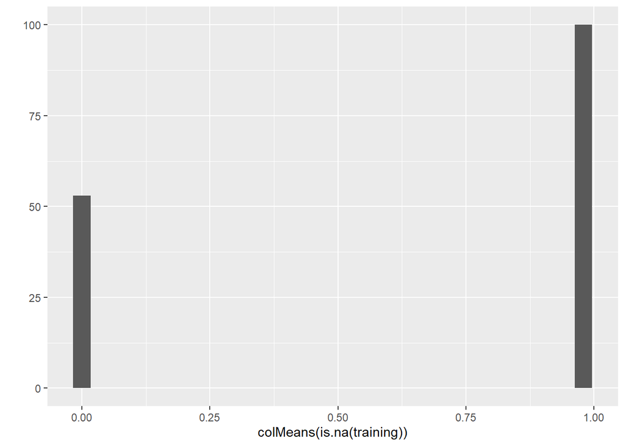

```r
## what is the distribution of proportion of missing values?
qplot(colMeans(is.na(training)))
```

```r
training <- training[ ,which(colMeans(!is.na(training)) > 0.9)]

dim(training[complete.cases(training), ])
```

```
## [1] 19622    53
```

Now we have data with no missing values, no imputation required.

Outcomes (*classe*) are well balanced across observations in the training set.

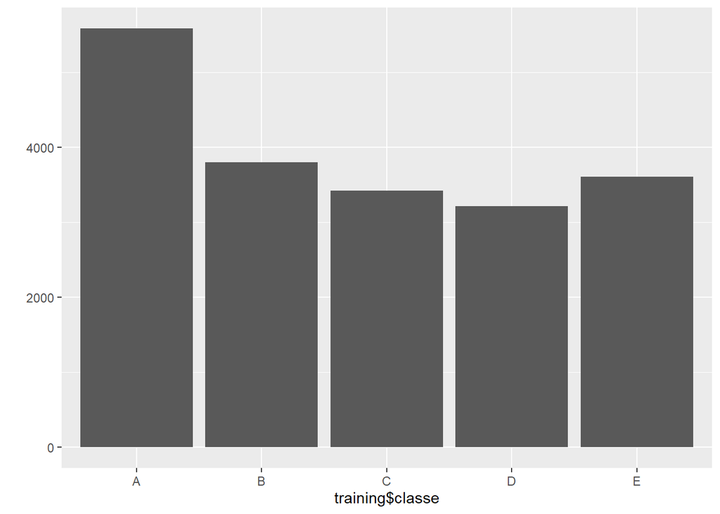

```r
qplot(training$classe)
```

*classe* values are slightly skewed towards “A”, but we will consider the data to be sufficiently balanced that we can take a random sample when creating the validation set.

### **Split training data into training and validation sets**

```r
## check dimensions of training set
dim(training)
```

```
## [1] 19622    53
```

```r
## split into 70% that will stay in training, 30% will go into validation
inTrain <- createDataPartition(y=training$classe,p=0.70, list = FALSE)

## create the validation set
validation <- training[-inTrain,]       ##create a validation set
## check dimensions
dim(validation)
```

```
## [1] 5885   53
```

```r
## now subset the training set
training <- training[inTrain,]            ##subset the training set
## check dimensions
dim(training)
```

```
## [1] 13737    53
```

### **Train prediction model**

```r
## set up training control options for repeated cross-validation ...
fit.control <- trainControl(method = "repeatedcv", number = 5, repeats = 5)

tic("fit rf model to training_PC")
modFit_rf <- train(classe ~ ., data=training, method="rf", trControl = fit.control, allowParallel = TRUE)
toc()
```

```
## fit rf model to training_PC: 1965.55 sec elapsed
```

### **Check accuracy against validation set**

Make predictions against validation set and estimate (out-of-sample) accuracy for model.

```r
## make predictions on validation set
pred_rf <- predict(modFit_rf, validation)
confusionMatrix(pred_rf, validation$classe)$overall
```

```
##       Accuracy          Kappa  AccuracyLower  AccuracyUpper   AccuracyNull AccuracyPValue
##      0.9943925      0.9929062      0.9921340      0.9961370      0.2844520      0.0000000
##  McnemarPValue
##            NaN
```

```r
## store out of sample accuracy
out_sample_accuracy <- confusionMatrix(pred_rf, validation$classe)$overall[['Accuracy']]
```

### **Load test set**

```r
test <- read.csv(file = "https://d396qusza40orc.cloudfront.net/predmachlearn/pml-testing.csv",stringsAsFactors = FALSE,na.strings=c("","NA"))

dim(test)
```

```
## [1]  20 160
```

```r
unique(test$user_name)
```

```
## [1] "pedro"    "jeremy"   "adelmo"   "eurico"   "carlitos" "charles"
```

```r
"classe" %in% names(test)
```

```
## [1] FALSE
```

### **Preprocess test set**

```r
## omit the same columns from test
test <- test[ ,which(names(test) %in% names(training))]
```

### **Make predictions against test set using trained model**

Predicted *classe* values are:

```r
Pred_test <- predict(modFit_rf, test)

formattable(data.frame("ID" = seq_along(Pred_test), "Predicted_classe" = Pred_test))
```

| ID | Predicted_classe |
| --- | --- |
| 1 | B |
| 2 | A |
| 3 | B |
| 4 | A |
| 5 | A |
| 6 | E |
| 7 | D |
| 8 | B |
| 9 | A |
| 10 | A |
| 11 | B |
| 12 | C |
| 13 | B |
| 14 | A |
| 15 | E |
| 16 | E |
| 17 | A |
| 18 | B |
| 19 | B |
| 20 | B |